# Final Project

## Start Summary Tables

Create summary tables * Ride count by Company * Ride count by Dropoff Area * Ride count by Pickup Area * Rice count, avg fare, avg distance by pickup area * Rice count, avg fare, avg distance by dropoffS area

```r
#Note: I am calling dplyr's functions directly to avoid issues with summarize
#Trips by Company
df %>% dplyr::group_by(company) %>% tally(sort=TRUE)
#Trips by Dropoff Area
df %>% dplyr::group_by(dropoff_area) %>% tally(sort=TRUE)
#Trips by Origination and Destination
df %>% dplyr::group_by(pickup_area,dropoff_area) %>% tally(sort=TRUE)
#Trips by Pickup Area
df %>% dplyr::group_by(pickup_area) %>% tally(sort=TRUE)
#Avg Fare and Distance by Pickup Area
df %>% dplyr::group_by(pickup_area) %>% dplyr::summarize(total_trips=n(),mean_fare = round(mean(fare,na.rm=TRUE),2),mean_distance=round(mean(trip_miles,na.rm=TRUE),1))
#Avg Fare and Distance by Dropoff Area
df %>% dplyr::group_by(dropoff_area) %>% dplyr::summarize(total_trips=n(),mean_fare = round(mean(fare,na.rm=TRUE),2),mean_distance=round(mean(trip_miles,na.rm=TRUE),1))
#Avg Fare and Distance by Pickup and Dropoff Areas
df %>% dplyr::group_by(pickup_area,dropoff_area) %>% dplyr::summarize(total_trips=n(),
  mean_fare = round(mean(fare,na.rm=TRUE),2),
  median_fare = round(median(fare,na.rm=TRUE),2),
  min_fare=round(min(fare,na.rm=TRUE),2),
  max_fare=round(max(fare,na.rm=TRUE),2),
  mean_distance=round(mean(trip_miles,na.rm=TRUE),1),
  median_distance=round(median(trip_miles,na.rm=TRUE),1),
  min_distance=round(min(trip_miles,na.rm=TRUE),1),
  max_distance=round(max(trip_miles,na.rm=TRUE),1)
  )  %>% arrange(desc(mean_fare))
```

```
## # A tibble: 114 x 2
##     company                                 n
##     <fct>                               <int>
##   1 NA                                 711959
##   2 Taxi Affiliation Services          599699
##   3 Dispatch Taxi Affiliation          182379
##   4 Blue Ribbon Taxi Association Inc.  134912
##   5 Chicago Elite Cab Corp.            124124
##   6 Choice Taxi Association            103413
##   7 Northwest Management LLC            60383
##   8 KOAM Taxi Association               26919
##   9 Top Cab Affiliation                 16375
##  10 T.A.S. - Payment Only               15128
##  11 Suburban Dispatch LLC                6586
##  12 Chicago Medallion Leasing INC        4699
```

[output cut: 6646 more lines]

Generate summary calculations by month/year and plot.

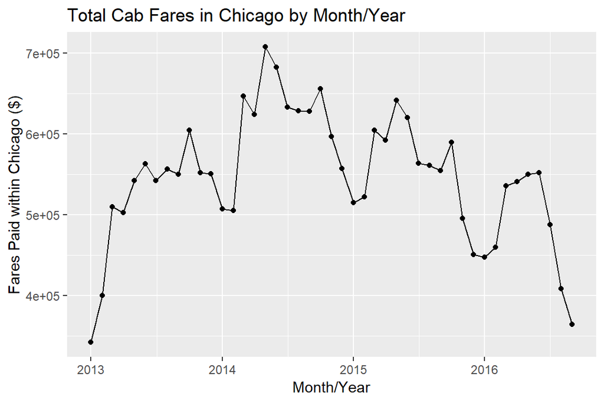

```r
fareByMonthYear <- df %>% drop_na(c("startDate","fare")) %>% filter(fare<1000) %>%
  dplyr::group_by(month=floor_date(startDate, "month")) %>%
   filter(month!="2016-10-01") %>% summarize(totalFares=sum(fare))
ggplot(fareByMonthYear, aes(x=month, y=totalFares, group=1))+
  geom_point()+geom_line()+ggtitle("Total Cab Fares in Chicago by Month/Year")+xlab("Month/Year")+ylab("Fares Paid within Chicago ($)")
```

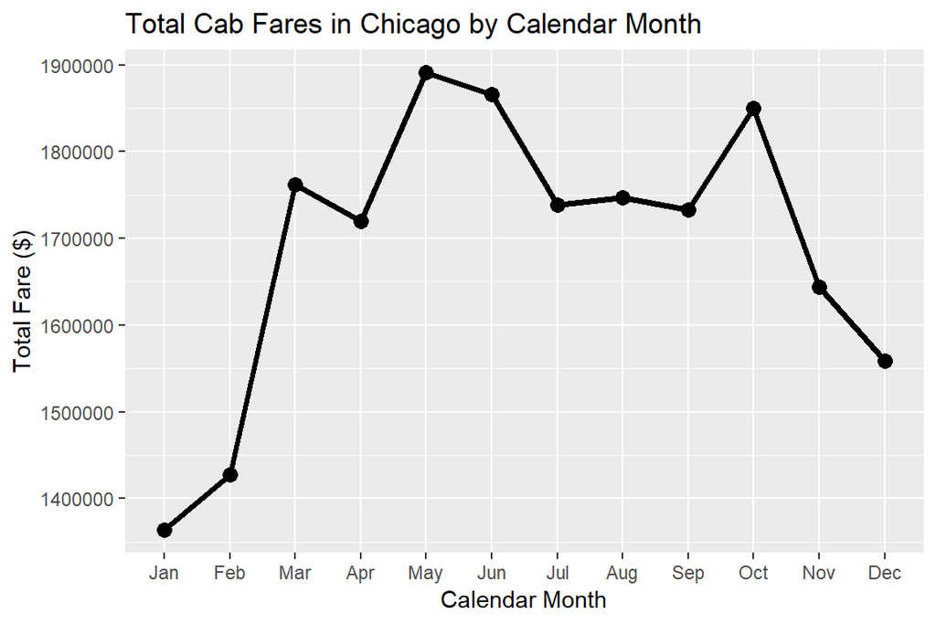

```r
#Drop all NA on-the-fly
fareByMonth <- df %>% drop_na(c("startDate","fare")) %>%  filter(year(endDate)!='2016') %>% filter(fare<1000) %>%
  dplyr::group_by(month=endMonth)  %>% summarize(total=sum(fare))
ggplot(fareByMonth, aes(x=month, y=total, group=1))+
  geom_point(size=3)+geom_line(size=1.25)+ggtitle("Total Cab Fares in Chicago by Calendar Month")+xlab("Calendar Month")+ylab("Total Fare ($)")
```

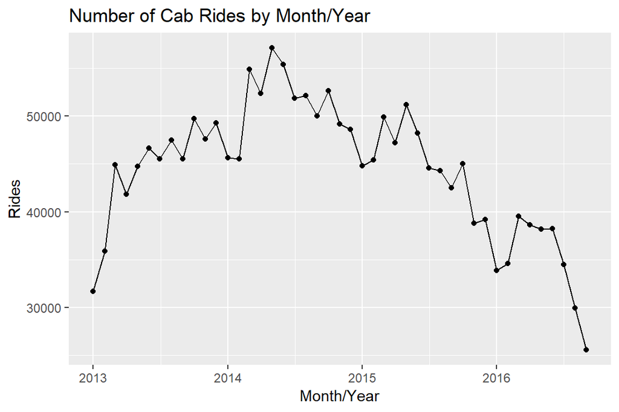

```r
#Throw out 10/2016 because zero rides
ridesByMonthYear <- df %>% dplyr::group_by(month=floor_date(df$startDate, "month")) %>%
   filter(month!="2016-10-01") %>% tally(sort=TRUE)
ggplot(ridesByMonthYear, aes(x=month, y=n, group=1))+
  geom_point()+geom_line()+ggtitle("Number of Cab Rides by Month/Year")+xlab("Month/Year")+ylab("Rides")
```

Let’s look at the total number of cab rides by calendar month. Since we only have data for the first 9 months of 2016, we drop all 2016 data to avoid introducing a bias in the trend.

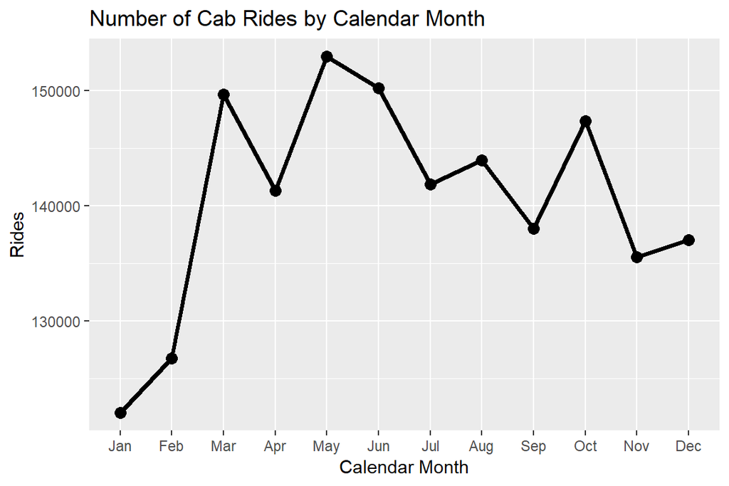

```r
#Drop all NA on-the-fly
ridesByMonth <- df %>% drop_na(c("endMonth")) %>%  filter(year(endDate)!='2016') %>%
  dplyr::group_by(month=endMonth)  %>%summarize(total=sum(!is.na(endMonth)))
ggplot(ridesByMonth, aes(x=month, y=total, group=1))+
  geom_point(size=3)+geom_line(size=1.25)+ggtitle("Number of Cab Rides by Calendar Month")+xlab("Calendar Month")+ylab("Rides")
```

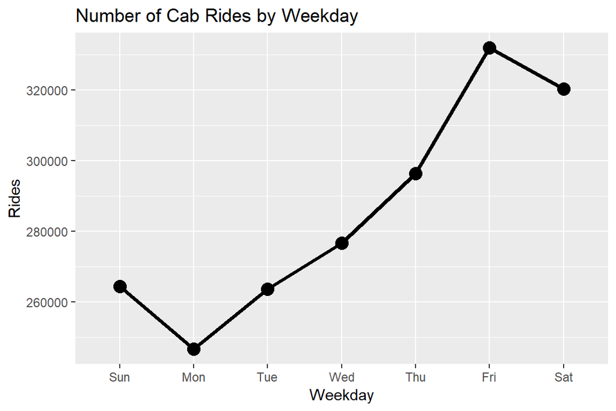

```r
#Drop all NA on-the-fly
ridesByWeekday<- df %>% drop_na(c("endDay")) %>% dplyr::group_by(weekday=endDay) %>%
   summarize(total=sum(!is.na(endDay)))
ggplot(ridesByWeekday, aes(x=weekday, y=total, group=1))+
  geom_point(size=4)+geom_line(size=1.25)+ggtitle("Number of Cab Rides by Weekday")+xlab("Weekday")+ylab("Rides")
```

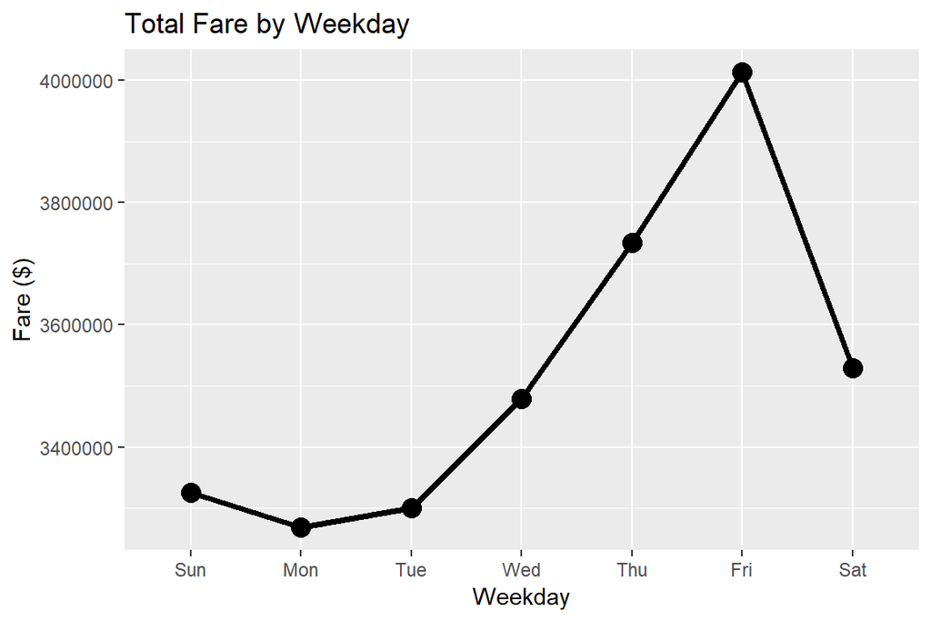

```r
#Drop all NA on-the-fly
fareByWeekday<- df %>% drop_na(c("endDay","fare")) %>% dplyr::group_by(weekday=endDay) %>%  filter(fare<1000) %>%
   summarize(total=sum(fare))
ggplot(fareByWeekday, aes(x=weekday, y=total, group=1))+
  geom_point(size=4)+geom_line(size=1.25)+ggtitle("Total Fare by Weekday")+xlab("Weekday")+ylab("Fare ($)")
```

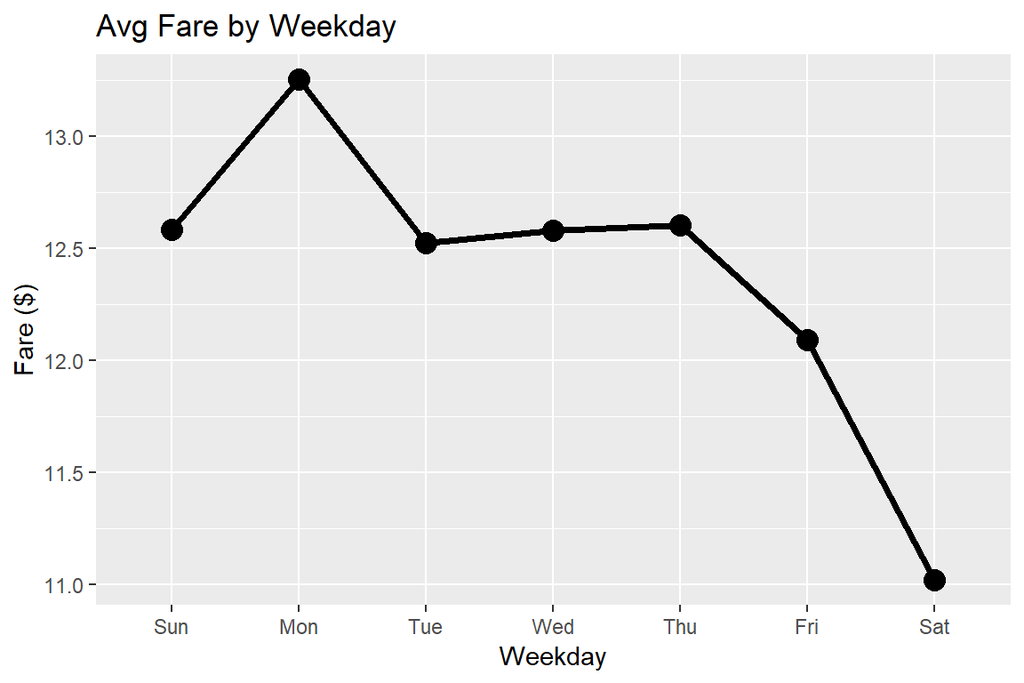

```r
#Drop all NA on-the-fly
avgFareByWeekday<- df %>% drop_na(c("endDay","fare")) %>% dplyr::group_by(weekday=endDay) %>%  filter(fare<1000) %>%
   summarize(mean=mean(fare))
ggplot(avgFareByWeekday, aes(x=weekday, y=mean, group=1))+
  geom_point(size=4)+geom_line(size=1.25)+ggtitle("Avg Fare by Weekday")+xlab("Weekday")+ylab("Fare ($)")
```

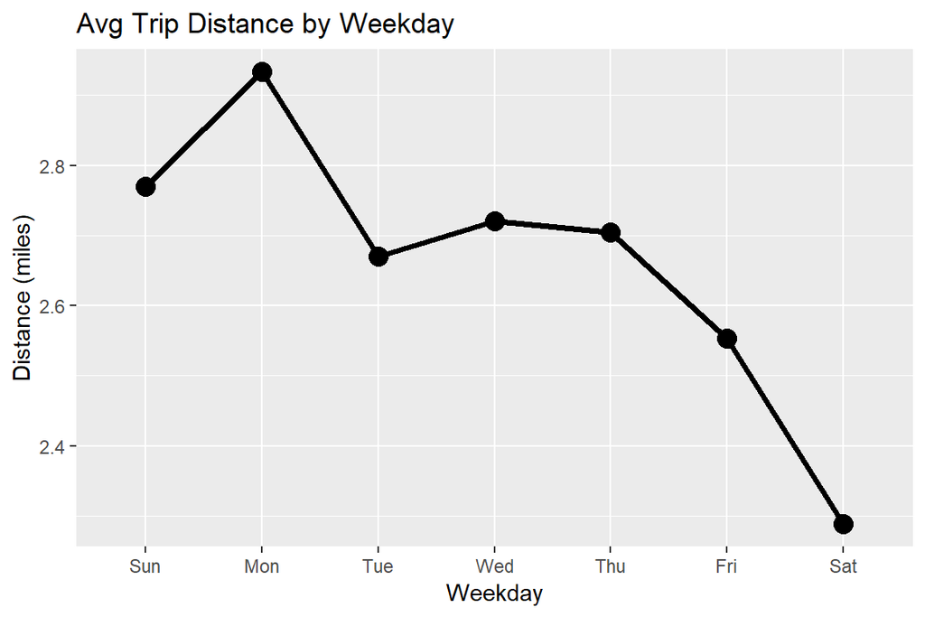

```r
#Drop all NA on-the-fly
avgDistanceByWeekday<- df %>% drop_na(c("endDay","trip_miles")) %>% dplyr::group_by(weekday=endDay) %>%  filter(trip_miles<1000) %>%
   summarize(mean=mean(trip_miles))
ggplot(avgDistanceByWeekday, aes(x=weekday, y=mean, group=1))+
  geom_point(size=4)+geom_line(size=1.25)+ggtitle("Avg Trip Distance by Weekday")+xlab("Weekday")+ylab("Distance (miles)")
```